# Logistic Regression: Challenger

Bikramjit Das

2025

# 1 Introduction

The dataset consists of 144 observations of 5 variables consisting of:

1. `Flight`: name of flight;
2. `Date`: date of flight;
3. `Field`: 1 if an O-ring fails and 0 otherwise;
4. `Temp`: Temperature in degrees Fahrenheit;
5. `Pres`: Leak check pressure in psi.

Each flight had 6 **O-rings**.

## 1.1 Data set

```r
rm(list=ls())
orings <- read.csv("Orings.csv")
str(orings)
```

```
## 'data.frame':    144 obs. of  5 variables:
##  $ Flight: chr  "1" "1" "1" "1" ...
##  $ Date  : chr  "4/12/1981" "4/12/1981" "4/12/1981" "4/12/1981" ...
##  $ Field : int  0 0 0 0 0 0 1 0 0 0 ...
##  $ Temp  : int  66 66 66 66 66 66 70 70 70 70 ...
##  $ Pres  : int  50 50 50 50 50 50 50 50 50 50 ...
```

```r
summary(orings)
```

```
##     Flight              Date               Field              Temp
##  Length:144         Length:144         Min.   :0.00000   Min.   :31.00
##  Class :character   Class :character   1st Qu.:0.00000   1st Qu.:66.75
##  Mode  :character   Mode  :character   Median :0.00000   Median :70.00
##                                        Mean   :0.07246   Mean   :67.96
##                                        3rd Qu.:0.00000   3rd Qu.:75.00
##                                        Max.   :1.00000   Max.   :81.00
##                                        NA's   :6
##       Pres
##  Min.   : 50.0
##  1st Qu.: 87.5
##  Median :200.0
##  Mean   :154.2
##  3rd Qu.:200.0
##  Max.   :200.0
##
```

Let us check the number of O-rings that have failed (out of 6 O-rings) in each of the flights launched.

```r
?tapply
tapply(orings$Field,orings$Flight,sum)
```

```
##    1    2    3 41-B 41-C 41-D 41-G    5 51-A 51-B 51-C 51-D 51-F 51-G 51-I 51-J
##    0    1    0    1    1    1    0    0    0    0    3    0    0    0    0    0
##    6 61-A 61-B 61-C 61-I    7    8    9
##    0    2    0    1   NA    0    0    0
```

```r
table(tapply(orings$Field,orings$Flight,sum))
```

```
##
##  0  1  2  3
## 16  5  1  1
```

## 1.2 Visualization

We plot the failures and temperatures. We use jitter plot to randomly perturb points by a small amount to see the points that lie on top of each other better.

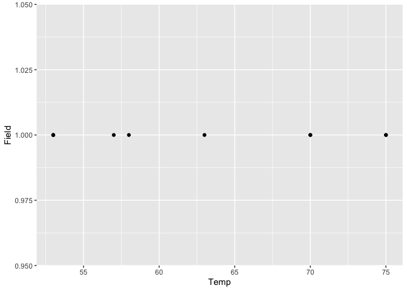

```r
library("ggplot2")

#qplot(Temp,Field,data=orings[orings$Field>0,])
ggplot(orings[orings$Field>0,],aes(Temp,Field)) + geom_point(na.rm=T)
```

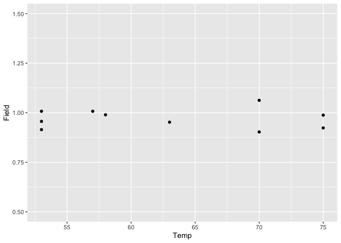

```r
ggplot(orings[orings$Field>0,],aes(Temp,Field)) + geom_jitter(na.rm=T,width=0,height=0.1)+ylim(c(0.5,1.5))
```

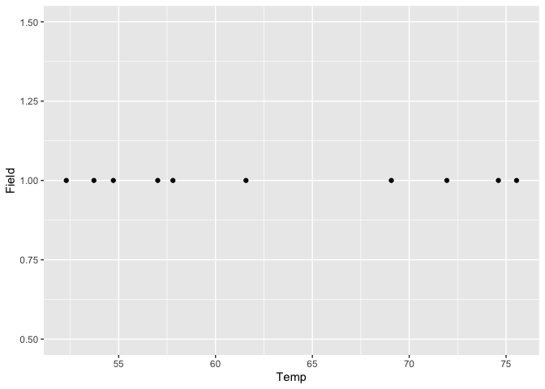

```r
ggplot(orings[orings$Field>0,],aes(Temp,Field)) + geom_jitter(na.rm=T,width=2,height=0)+ylim(c(0.5,1.5))
```

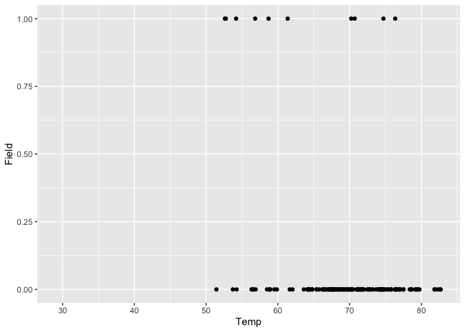

```r
ggplot(orings,aes(Temp,Field)) + geom_jitter(na.rm=T,height=0,width=2)
```

The plots of temperature with failures only and the plot of temperatures with both failures and non-failures provide different insights. In the former, failures occur across the range with some more at the extremes. In the second case, it is much clearer that there are fewer failures at higher temperatures. It is believed that analysis of plots such as the first one led the managers to conclude that there was not a significant influence of low temperatures.

# 2 Fitting a model

## 2.1 Linear regression

We fit a linear regression model first.

### 2.1.1 Model with temperature and pressure

```r
model1 <- lm(Field~Temp+Pres,data=orings)
summary(model1)
```

```
##
## Call:
## lm(formula = Field ~ Temp + Pres, data = orings)
##
## Residuals:
##      Min       1Q   Median       3Q      Max
## -0.27680 -0.09548 -0.03457 -0.00874  0.99126
##
## Coefficients:
##               Estimate Std. Error t value Pr(>|t|)
## (Intercept)  0.7264305  0.2181384   3.330  0.00112 **
## Temp        -0.0106657  0.0030704  -3.474  0.00069 ***
## Pres         0.0005783  0.0003176   1.821  0.07088 .
## ---
## Signif. codes:  0 '***' 0.001 '**' 0.01 '*' 0.05 '.' 0.1 ' ' 1
##
## Residual standard error: 0.2487 on 135 degrees of freedom
##   (6 observations deleted due to missingness)
## Multiple R-squared:  0.09941,    Adjusted R-squared:  0.08607
## F-statistic: 7.451 on 2 and 135 DF,  p-value: 0.0008524
```

### 2.1.2 Model with temperature

Now we use a model with only Temperature as a predictor.

```r
model2 <- lm(Field~Temp,data=orings)
summary(model2)
```

```
##
## Call:
## lm(formula = Field ~ Temp, data = orings)
##
## Residuals:
##      Min       1Q   Median       3Q      Max
## -0.24546 -0.09925 -0.06792 -0.00526  0.98429
##
## Coefficients:
##              Estimate Std. Error t value Pr(>|t|)
## (Intercept)  0.798942   0.216289   3.694 0.000319 ***
## Temp        -0.010443   0.003094  -3.375 0.000961 ***
## ---
## Signif. codes:  0 '***' 0.001 '**' 0.01 '*' 0.05 '.' 0.1 ' ' 1
##
## Residual standard error: 0.2509 on 136 degrees of freedom
##   (6 observations deleted due to missingness)
## Multiple R-squared:  0.0773, Adjusted R-squared:  0.07051
## F-statistic: 11.39 on 1 and 136 DF,  p-value: 0.0009612
```

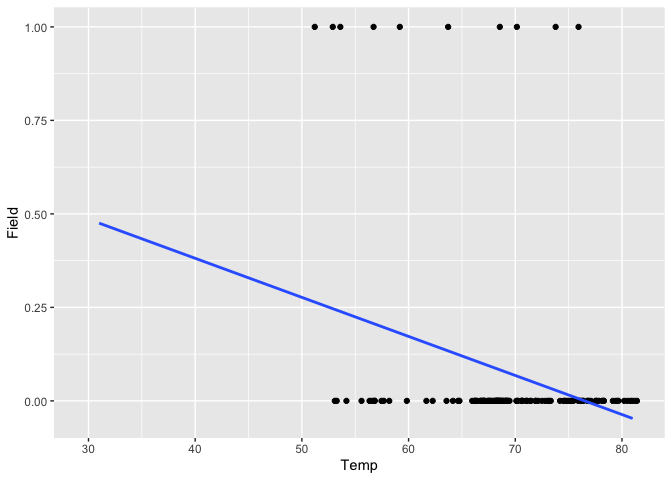

```r
ggplot(orings,aes(Temp,Field)) + geom_jitter(na.rm=T,height=0,width=2)+geom_smooth(method="lm",se=F,na.rm=T,fullrange=T)
```

The result indicates that the linear fit is not particularly convincing with a small value of R-squared, though it does identify that temperature has a significant effect and it is a negative impact.

## 2.2 Logistic regression

Fitting a logistic regression model: `glm()` is a generalized linear model that can be used to fit a logistic regression model by choosing `family=binomial`.

### 2.2.1 Model with temperature and pressure

```r
model3 <- glm(Field~Temp+Pres, data=orings,family="binomial")
summary(model3)
```

```
##
## Call:
## glm(formula = Field ~ Temp + Pres, family = "binomial", data = orings)
##
## Coefficients:
##              Estimate Std. Error z value Pr(>|z|)
## (Intercept)  3.958071   3.497847   1.132  0.25781
## Temp        -0.119355   0.044945  -2.656  0.00792 **
## Pres         0.008692   0.007689   1.130  0.25829
## ---
## Signif. codes:  0 '***' 0.001 '**' 0.01 '*' 0.05 '.' 0.1 ' ' 1
##
## (Dispersion parameter for binomial family taken to be 1)
##
##     Null deviance: 71.751  on 137  degrees of freedom
## Residual deviance: 60.470  on 135  degrees of freedom
##   (6 observations deleted due to missingness)
## AIC: 66.47
##
## Number of Fisher Scoring iterations: 6
```

### 2.2.2 Model with temperature

```r
model4 <- glm(Field~Temp,data=orings,family=binomial)
summary(model4)
```

```
##
## Call:
## glm(formula = Field ~ Temp, family = binomial, data = orings)
##
## Coefficients:
##             Estimate Std. Error z value Pr(>|z|)
## (Intercept)  6.75183    2.97991   2.266  0.02346 *
## Temp        -0.13971    0.04647  -3.007  0.00264 **
## ---
## Signif. codes:  0 '***' 0.001 '**' 0.01 '*' 0.05 '.' 0.1 ' ' 1
##
## (Dispersion parameter for binomial family taken to be 1)
##
##     Null deviance: 71.751  on 137  degrees of freedom
## Residual deviance: 62.083  on 136  degrees of freedom
##   (6 observations deleted due to missingness)
## AIC: 66.083
##
## Number of Fisher Scoring iterations: 6
```

### 2.2.3 Model comparison

```r
model3$coefficients
```

```
##  (Intercept)         Temp         Pres
##  3.958070598 -0.119355166  0.008691799
```

```r
model3$aic
```

```
## [1] 66.4705
```

Model 3 describes  
$Prob(Fail = 1) = exp(3.95-0.119 Temp + 0.008 Pres)/(1+exp(3.95-0.119Temp+0.008Pres)).$  
The result indicates that Temp is significant at the 5% level.

```r
model4$coefficients
```

```
## (Intercept)        Temp
##   6.7518341  -0.1397096
```

```r
model4$aic
```

```
## [1] 66.08252
```

Model 4 has a fit given by  
$P(Fail=1) = exp(6.75-0.1397Temp)/(1+exp(6.75-0.1397Temp))$.  
In terms of AIC, Model 4 is preferred to Model 3. We drop the pressure variable in this example.

# 3 Predictions

## 3.1 Predicting in logit scale and probability

```r
#predict(model4,newdata=orings[144,]) # predicts on log(odds) scale
predict(model4,newdata=orings[144,],type="response")
```

```
##       144
## 0.9184025
```

## 3.2 The logistic curve

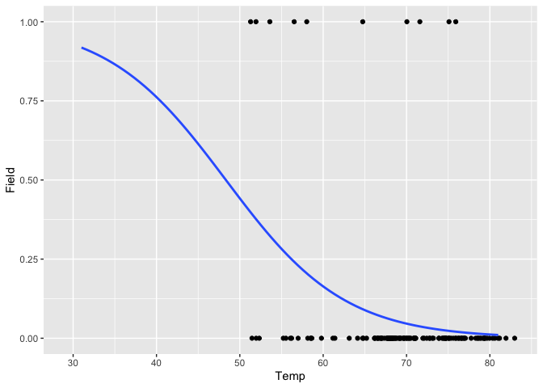

```r
ggplot(orings,aes(Temp,Field)) + geom_jitter(na.rm=T,height=0,width=2)+geom_smooth(method="glm",se=F,na.rm=T,fullrange=T,method.args = list(family = "binomial"))
```

The predicted probability of failure under the model (for a temperature of 31 degree Fahrenheit) is 0.918.

Developing a predictive rule (classifier) and tabulating confusion matrices.  
Here we are still evaluating this with the training data. Typically we will use a test data to check on the results.

# 4 Quality of fit

## 4.1 Confusion matrix

```r
Pred <- predict(model4,newdata=orings,type="response")
t1<-table(Pred[1:138]>0.5,orings$Field[1:138])
t2<-table(Pred[1:138]>0.25,orings$Field[1:138])
t3<-table(Pred[1:138]>0.2,orings$Field[1:138])
t1
```

```
##
##           0   1
##   FALSE 128  10
```

```r
t2
```

```
##
##           0   1
##   FALSE 125   7
##   TRUE    3   3
```

```r
t2
```

```
##
##           0   1
##   FALSE 125   7
##   TRUE    3   3
```

## 4.2 Accuracy, Specifity, Sensitivity

```r
Spec_0.5<- 128/128
Sens_0.5<- 0/10
Acc_0.5<- 128/138
Spec_0.5
```

```
## [1] 1
```

```r
Sens_0.5
```

```
## [1] 0
```

```r
Acc_0.5
```

```
## [1] 0.9275362
```

```r
Spec_0.25<- t2[1,1]/sum(t2[,1])
Sens_0.25<- t2[2,2]/sum(t2[,2])
Acc_0.25<- (t2[1,1]+t2[2,2])/sum(t2)
Spec_0.25
```

```
## [1] 0.9765625
```

```r
Sens_0.25
```

```
## [1] 0.3
```

```r
Acc_0.25
```

```
## [1] 0.9275362
```

```r
Spec_0.2<- t3[1,1]/sum(t2[,1])
Sens_0.2<- t3[2,2]/sum(t3[,2])
Acc_0.2<-(t3[1,1]+t2[2,2])/sum(t3)
Spec_0.2
```

```
## [1] 0.8984375
```

```r
Sens_0.2
```

```
## [1] 0.5
```

```r
Acc_0.2
```

```
## [1] 0.8550725
```

## 4.3 ROC: receiver operating characteristic curve

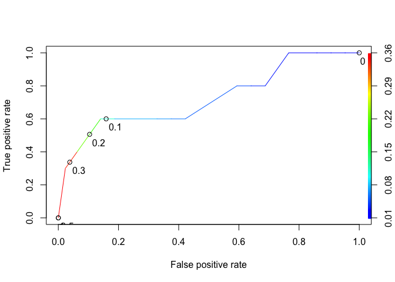

```r
#install.packages("ROCR")
library(ROCR)
ROCRpred <- prediction(Pred[1:138],orings$Field[1:138])
ROCRperf <- performance(ROCRpred,x.measure="fpr",measure="tpr")
#plot(ROCRperf)
plot(ROCRperf, colorize=T,print.cutoffs.at=c(0,0.1,0.2,0.3,0.5,1), text.adj=c(-0.2,1.7))
```

```r
as.numeric(performance(ROCRpred,measure="auc")@y.values)
```

```
## [1] 0.725
```

The AUC for this example is 0.725.